# Projet de visualisation des données

# 1 Introduction

Les maladies cardiovasculaires sont une cause majeure de mortalité dans le monde. La détection et l’intervention précoces sont essentielles pour prévenir celles-ci. Certains facteurs sont bien connus comme étant des symptômes de maladies cardiaques.

Nous allons analyser un jeu de données pour confirmer ces symptômes, c’est-à-dire vérifier s’ils ont un réel impact sur la santé cardiaque d’un individu. Puis, à partir de ce même jeu de données, nous essaierons de prédire au mieux la variable cible grâce à des modèles statistiques dont nous étudierons les performances.

La variable cible est la variable nommée *target*. Elle représente l’état du patient. Cette variable vaut 0 si l’individu est en bonne santé et vaut 1 si l’individu souffre d’une maladie cardiaque.

# 2 Observation et préparation des données

## 2.1 Observation des données

Dans un premier temps, on importe les données et on affiche un aperçu de celles-ci pour les observer rapidement.

```r
# Téléchargement du jeu de données
df <- read.csv("heart.csv")

# Affichage du jeu de données sous forme de tableau
rmarkdown::paged_table(df)
```

| age | sex | cp | trestbps | chol | fbs | restecg | thalach | exang | oldpeak | slope | ca | thal | target |
| --- | --- | --- | --- | --- | --- | --- | --- | --- | --- | --- | --- | --- | --- |
| 63 | 1 | 3 | 145 | 233 | 1 | 0 | 150 | 0 | 2.3 | 0 | 0 | 1 | 1 |
| 37 | 1 | 2 | 130 | 250 | 0 | 1 | 187 | 0 | 3.5 | 0 | 0 | 2 | 1 |
| 41 | 0 | 1 | 130 | 204 | 0 | 0 | 172 | 0 | 1.4 | 2 | 0 | 2 | 1 |
| 56 | 1 | 1 | 120 | 236 | 0 | 1 | 178 | 0 | 0.8 | 2 | 0 | 2 | 1 |
| 57 | 0 | 0 | 120 | 354 | 0 | 1 | 163 | 1 | 0.6 | 2 | 0 | 2 | 1 |
| 57 | 1 | 0 | 140 | 192 | 0 | 1 | 148 | 0 | 0.4 | 1 | 0 | 1 | 1 |
| 56 | 0 | 1 | 140 | 294 | 0 | 0 | 153 | 0 | 1.3 | 1 | 0 | 2 | 1 |
| 44 | 1 | 1 | 120 | 263 | 0 | 1 | 173 | 0 | 0.0 | 2 | 0 | 3 | 1 |
| 52 | 1 | 2 | 172 | 199 | 1 | 1 | 162 | 0 | 0.5 | 2 | 0 | 3 | 1 |
| 57 | 1 | 2 | 150 | 168 | 0 | 1 | 174 | 0 | 1.6 | 2 | 0 | 2 | 1 |

[output cut: 293 more lines]

On affiche aussi la dimension du jeu de données :

```r
# Création d'un dataframe contenant les dimensions
dim <- data.frame(dim(df))
rownames(dim) <- c("Nombre de lignes","Nombre de colonnes") # Nom des lignes du tableau
colnames(dim) <- c("") # Nom de la colonne du tableau

# Affichage des dimensions du jeu de données dans un tableau
dim %>%
  kbl(caption = "Dimension du jeu de données") %>%
  kable_styling()
```

Table 2.1: Dimension du jeu de données

| Nombre de lignes | 303 |
| --- | --- |
| Nombre de colonnes | 14 |

Le jeu de données comporte 303 lignes, c’est-à-dire 303 observations (individus) et 14 colonnes, c’est-à-dire 14 variables. 13 d’entre elles sont les variables explicatives et la dernière est la variable cible (la variable *target* comme vu en introduction).

On regarde ensuite le type des variables, pour savoir si elles sont quantitatives ou qualitatives ; numériques ou catégorielles, bien qu’on en ait déjà une idée grâce à l’affichage précédent. Le tableau suivant présente une description récapitulative des variables. On pourra trouver une description plus détaillée de celles-ci dans la notice du projet.

```r
# Affichage de la définition des variables dans un tableau
kable(caption = "Définition des variables", # Titre du tableau
  # Création d'un dataframe avec les variables, leur description, leur type et leur support
  data.frame(
        Variable = c(
          "age", "sex", "cp", "trestbps", "chol", "fbs", "restecg", "thalach",
          "exang", "oldpeak", "slope", "ca", "thal"),
        Description = c(
          "Age de l'individu",
          "Sexe de l'individu",
          "Douleur thoracique",
          "Pression artérielle au repos en mmHg",
          "Niveau de cholestérol sérique du patient en mg/dL",
          "Taux de glycémie à jeun",
          "Résultats électrocardiographiques au repos",
          "Fréquence cardiaque maximale atteinte",
          "Angine de poitrine induite par l'exercice",
          "Dépression du segment ST induite par l'exercice par rapport au repos",
          "Pente du segment ST de pointe de l'exercice",
          "Nombre de vaisseaux principaux colorés par la flourosopie",
          "Flux sanguin vers le muscle cardiaque "),
        Type = c(
          rep("Entier", 9),
          "Réel",
          rep("Entier", 3)),
        Support = c(
          "〚29;77⟧", "{0, 1}", "{0, 1, 2, 3}", "〚94;200⟧", "〚126; 564⟧", "{0, 1}",
          "{0, 1, 2}", "〚71;202⟧", "{0, 1}", "[0, 6.2]", "{0, 1, 2}", "〚0;4⟧", "{0, 1, 2, 3}")),
    booktabs=TRUE) # Mise en page et style du tableau
```

Table 2.2: Définition des variables

| Variable | Description | Type | Support |
| --- | --- | --- | --- |
| age | Age de l’individu | Entier | 〚29;77⟧ |
| sex | Sexe de l’individu | Entier | {0, 1} |
| cp | Douleur thoracique | Entier | {0, 1, 2, 3} |
| trestbps | Pression artérielle au repos en mmHg | Entier | 〚94;200⟧ |
| chol | Niveau de cholestérol sérique du patient en mg/dL | Entier | 〚126; 564⟧ |
| fbs | Taux de glycémie à jeun | Entier | {0, 1} |
| restecg | Résultats électrocardiographiques au repos | Entier | {0, 1, 2} |
| thalach | Fréquence cardiaque maximale atteinte | Entier | 〚71;202⟧ |
| exang | Angine de poitrine induite par l’exercice | Entier | {0, 1} |
| oldpeak | Dépression du segment ST induite par l’exercice par rapport au repos | Réel | [0, 6.2] |
| slope | Pente du segment ST de pointe de l’exercice | Entier | {0, 1, 2} |
| ca | Nombre de vaisseaux principaux colorés par la flourosopie | Entier | 〚0;4⟧ |
| thal | Flux sanguin vers le muscle cardiaque | Entier | {0, 1, 2, 3} |

Les variables sont toutes quantitatives et de type entier sauf *oldpeak* qui est un réel.  
On a des variables

- catégorielles : *sex, cp, fbs, restecg, exang, slope, ca* et *thal* ;
- numériques : *age, trestbps, chol, thalach* et *oldpeak*.

**Remarque** : les variables *sex, cp, fbs, restecg, exang, slope, ca* et *thal* sont des variables numériques qu’on a classifié de catégorielles. Ces variables sont en fait des variables catégorielles, dont les catégories ont été présentées dans la notice, qui ont été “transformées” en variables numériques pour faciliter leur utilisation.

## 2.2 Valeurs manquantes

On vérifie s’il y a des valeurs manquantes. Si c’est le cas, il faudra y remédier. Le tableau ci-dessous affiche le nombre de valeur manquante par variable.

```r
# Vérification des valeurs manquantes dans le dataframe
val_manquantes <- sapply(df, function(x) sum(is.na(x)))

# Affichage du nombre de valeurs manquantes par variable dans un tableau
val_manq <- data.frame(val_manquantes) # Création d'un dataframe avec le nombre de valeurs manquantes
colnames(val_manq) <- c("Nombre de valeur manquante") # Nom de la colonne du tableau
val_manq %>%
  kbl(caption = "Nombre de valeur manquante par variable") %>% # Titre
  kable_styling() # Mise en page et style du tableau
```

Table 2.3: Nombre de valeur manquante par variable

|  | Nombre de valeur manquante |
| --- | --- |
| age | 0 |
| sex | 0 |
| cp | 0 |
| trestbps | 0 |
| chol | 0 |
| fbs | 0 |
| restecg | 0 |
| thalach | 0 |
| exang | 0 |
| oldpeak | 0 |
| slope | 0 |
| ca | 0 |
| thal | 0 |
| target | 0 |

Il n’y a donc pas de valeurs manquantes dans notre jeu de données.

## 2.3 Distribution des variables

Après avoir bien observé le jeu de données, passons à l’étude graphique de la distribution des variables.

### 2.3.1 Distribution de la variable cible

On étudie dans un premier temps la distribution de la variable cible puis celle des variables explicatives.

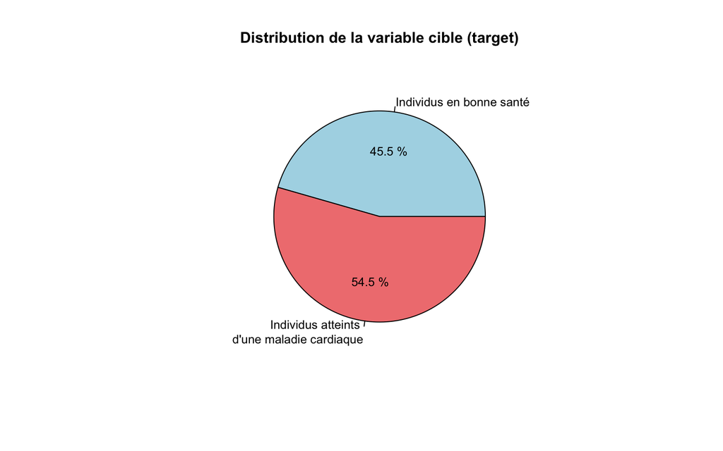

```r
# Création d'un camembert avec les pourcentages
pie(table(df$target), #  Table des effectifs pour la variable target
    main = "Distribution de la variable cible (target)", # Titre du graphique
    labels = c("Individus en bonne santé",
               "Individus atteints \nd'une maladie cardiaque"), # Légende
    col = c("lightblue", "lightcoral"), # Couleur des secteurs
    cex = 0.8, # Taille de la légende
    cex.main = 1) # Taille du titre

# Création d'une fonction qui ajoute les valeurs en tant qu'étiquettes au centre (fonction créée par chatgpt)
text_pie = function(vector, labels = c(), cex = 0.8) {
     vector = vector / sum(vector) * 2 * pi
     temp = c()
     j = 0
     l = 0
     for (i in 1:length(vector)) {
          k = vector[i] / 2
          j =  j + l + k
          l = k
          text(cos(j) / 2, sin(j) / 2, labels[i], cex = cex)
     }
     vector = temp
}

# Ajout des étiquettes
percent_values <- round(100 * prop.table(table(df$target)), 1) # Calcul des pourcentages arrondis
percent <- paste(percent_values, "%") # Ajout du sigle %
text_pie(percent_values,
         c(percent[1], percent[2]),
         cex = 0.8)
```

Le jeu de données est à peu près équilibré : on a environ 50% (54.5%) d’individus malades et 50% (45.5%) d’individus sains dans le jeu de données.

### 2.3.2 Distribution des variables explicatives

On affiche maintenant la distribution des variables catégorielles. Cela va nous permettre d’observer les catégories de variable qui prédominent par rapport aux autres catégories de cette même variable.

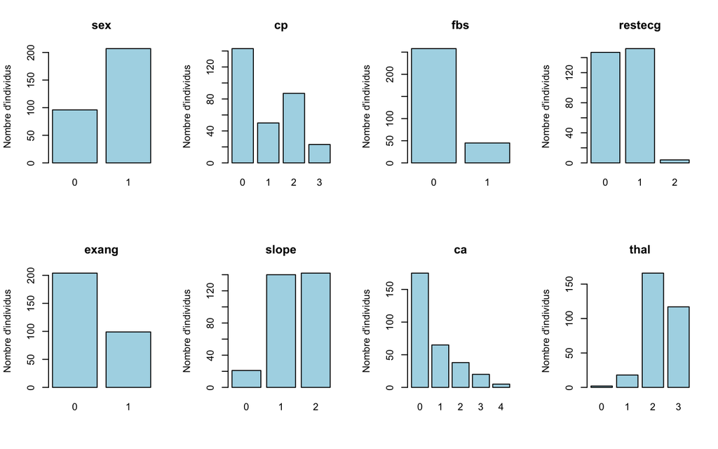

```r
# Création d'un vecteur avec les variables catégorielles
categorical_var <- c("sex", "cp", "fbs", "restecg", "exang", "slope", "ca", "thal")

# Organisation des graphiques en une grille 2x4
par(mfrow = c(2, 4))

# Boucle qui crée un histogramme en baton par chaque variable catégorielle
for (var in categorical_var) {
  barplot(table(df[[var]]),
          col = "lightblue", # Couleur de l'histogramme
          main = var, # Titre de l'histogramme
          ylab = "Nombre d'individus") # Nom de l'axe des ordonnées
}
```

On regarde maintenant la distribution des variables numériques. On trace un histogramme et le boxplot asssocié pour chaque variable. Le boxplot nous permet d’avoir la moyenne de chaque variable et d’observer les éventuelles valeurs aberrantes.

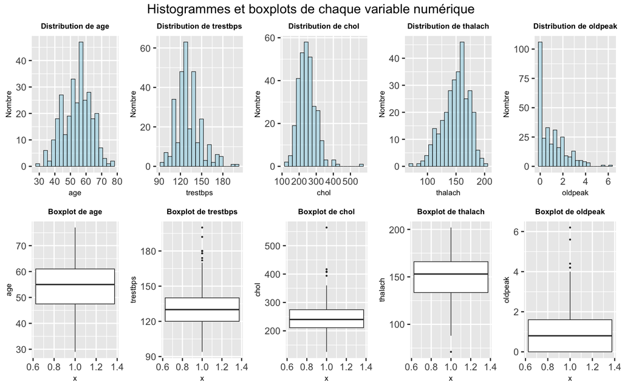

```r
# Création d'un vecteur avec les variables numériques
numerical_var <- c("age", "trestbps", "chol", "thalach", "oldpeak")

# Création de listes pour les histogrammes et les boxplots
hist_plots <- list()
box_plots <- list()

# Boucle pour créer les histogrammes et les boxplots pour chaque variable numérique
for (var in numerical_var) {
  # Histogramme
  histo <- ggplot(df, aes(x = .data[[var]])) +
    geom_histogram(fill = "lightblue", # Couleur de remplissage
                   color = "black", # Couleur des contours
                   bins = 20, # Nombre de catégories
                   alpha = 0.7, # Transparence de la couleur de remplissage
                   linewidth = 0.2) + # Épaisseur des contours
    labs(title = paste("Distribution de", var), # Titre des histogrammes
         x = var, # Nom de l'axe des abscisses
         y = "Nombre") + # Nom de l'axe des ordonnées
    theme(plot.title = element_text(hjust = 0.5, # Position du titre
                                  size = 7, # Taille du titre
                                  face = "bold"), # Titre en gras
        axis.title.x = element_text(size = 7), # Taille du nom de l'axe des abscisses
        axis.title.y = element_text(size = 7))  # Taille du nom de l'axe des ordonnée

  # Boxplot
  boxplot <- ggplot(df, aes(x = 1, y = .data[[var]])) +
    geom_boxplot(linewidth = 0.3, # Épaisseur des contours
                 outlier.size = 0.2) + # Taille des outliers
    labs(title = paste("Boxplot de", var)) + # Titre des boxplots
    theme(plot.title = element_text(hjust = 0.5, # Position du titre
                                  size = 7, # Taille du titre
                                  face = "bold"), # Titre en gras
        axis.title.x = element_text(size = 7), # Taille du nom de l'axe des abscisses
        axis.title.y = element_text(size = 7)) # Taille du nom de l'axe des ordonnée

  # Stockage des histogrammes et des boxplots dans les listes
  hist_plots[[var]] <- histo
  box_plots[[var]] <- boxplot
}

# Organisation des graphiques dans une grille 5x2
grid.arrange(grobs = c(hist_plots, box_plots),
             ncol = 5,
             top = "Histogrammes et boxplots de chaque variable numérique") # Titre
```

Grâce à ces graphiques ont peut observer que :

- *age* : les individus ont entre 29 et 77 ans avec une moyenne d’âge de 54 ans.
- *trestbps* : la pression artérielle au repos de la plupart des individus est supérieure à 120 mmHg, ce qui est un niveau élevé voir à risque.
- *chol* : la plupart des individus ont un niveau de cholestérol sérique entre 200 et 300 mg/dL, ce qui est très élevé.
- *thalach* : la fréquence cardiaque maximale atteinte est entre 100 et 200 bpm, ce qui semble tout à fait normal car celle-ci diminue avec l’âge et dans notre jeu de données, il y a toutes les catégories d’âge.
- *oldpeak* : environ 1/3 des individus ont une dépression ST proche de 0. Les autres individus ont des valeurs plus élevées de dépression ST.

On peut de plus observer certaines valeurs atypiques pour les variables *trestbps, chol, thalach* et *oldpeak*. Ce sont des valeurs extrêmes mais pas aberrantes (ce ne sont probablement pas des erreurs de saisie) donc on les garde.

## 2.4 Corrélations entre les variables

### 2.4.1 Corrélations entre les variables explicatives

On étudie maintenant s’il y a des corrélations entre les variables explicatives. On affiche pour cela la matrice des corrélations sous forme de graphique corrplot.

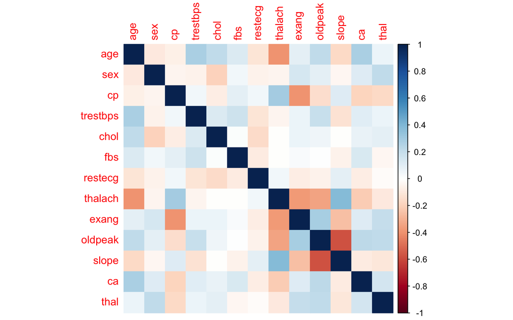

```r
# Plot des corrélations entre les variables explicatives
corrplot(cor(df[, 1:13]), method = "color")
```

D’après ce graphique, les variables ne semblent pas très corrélées. Nous pouvons cependant porter notre attention sur les 5 couples de variables les plus corrélés.

Le premier couple de variables est celui composé des variables *oldpeak* et *slope*. Cette corrélation semble tout à fait intuitive car on rappelle que oldpeak représente la dépression ST induite par l’exercice par rapport au repos et que slope est la pente du segment ST de pointe de l’exercice.

De plus, les variables *age* et *thalach* semblent avoir un coefficient de corrélation plus élevé que les autres variables ; ce qui est cohérent car, comme vu dans la description détaillée des variables (dans la notice), la fréquence cardiaque maximale diminue avec l’âge (on le vérifie plus bas).

Les variables *exang* et *cp* ont aussi un coefficient de corrélation de couleur foncée. Là encore, cette corrélation n’est pas aberrante car ces variables concernent toutes les 2 des douleurs thoraciques.

Le couple de variables *slope/thalach* est lui aussi un couple qui semble avoir un coefficient de corrélation plus élevé que la plupart des autres couples de variables.

Enfin le couple *thalach* et *exang* est le dernier couple qui se détache des autres par la valeur, plutôt élevée, de son coefficient de corrélation.

On affiche la matrice des corrélations pour voir plus précisément les coefficients de corrélations. Les coefficients dont la valeur absolue est supérieure à 0.35 sont affichés en rouge.

```r
# Calcul des corrélations entre les variables explicatives
correlation_matrix <- cor(df[, 1:13])

# Fonction pour formater les coefficients de corrélation (pour colorer les coefficients dont la valeur absolue est supérieure à 0.35 et arrondir les coefficients au centième près)
format_correlation <- function(x) {
  if (abs(x) > 0.35) {
    paste0("<span style='color: red; font-weight: bold;'>", round(x, 2), "</span>")
  } else {
    round(x, 2)
  }
}

# Application de la fonction de formatage à la matrice de corrélation
formatted_correlation_matrix <- apply(correlation_matrix, 1, function(row) {
  sapply(row, format_correlation)
})

# Affichage de la matrice de corrélation avec la mise en forme personnalisée
kable(formatted_correlation_matrix,
      format = "html",
      escape = FALSE) %>%
  kable_styling()
```

|  | age | sex | cp | trestbps | chol | fbs | restecg | thalach | exang | oldpeak | slope | ca | thal |
| --- | --- | --- | --- | --- | --- | --- | --- | --- | --- | --- | --- | --- | --- |
| age | 1 | -0.1 | -0.07 | 0.28 | 0.21 | 0.12 | -0.12 | -0.4 | 0.1 | 0.21 | -0.17 | 0.28 | 0.07 |
| sex | -0.1 | 1 | -0.05 | -0.06 | -0.2 | 0.05 | -0.06 | -0.04 | 0.14 | 0.1 | -0.03 | 0.12 | 0.21 |
| cp | -0.07 | -0.05 | 1 | 0.05 | -0.08 | 0.09 | 0.04 | 0.3 | -0.39 | -0.15 | 0.12 | -0.18 | -0.16 |
| trestbps | 0.28 | -0.06 | 0.05 | 1 | 0.12 | 0.18 | -0.11 | -0.05 | 0.07 | 0.19 | -0.12 | 0.1 | 0.06 |
| chol | 0.21 | -0.2 | -0.08 | 0.12 | 1 | 0.01 | -0.15 | -0.01 | 0.07 | 0.05 | 0 | 0.07 | 0.1 |
| fbs | 0.12 | 0.05 | 0.09 | 0.18 | 0.01 | 1 | -0.08 | -0.01 | 0.03 | 0.01 | -0.06 | 0.14 | -0.03 |
| restecg | -0.12 | -0.06 | 0.04 | -0.11 | -0.15 | -0.08 | 1 | 0.04 | -0.07 | -0.06 | 0.09 | -0.07 | -0.01 |
| thalach | -0.4 | -0.04 | 0.3 | -0.05 | -0.01 | -0.01 | 0.04 | 1 | -0.38 | -0.34 | 0.39 | -0.21 | -0.1 |
| exang | 0.1 | 0.14 | -0.39 | 0.07 | 0.07 | 0.03 | -0.07 | -0.38 | 1 | 0.29 | -0.26 | 0.12 | 0.21 |
| oldpeak | 0.21 | 0.1 | -0.15 | 0.19 | 0.05 | 0.01 | -0.06 | -0.34 | 0.29 | 1 | -0.58 | 0.22 | 0.21 |
| slope | -0.17 | -0.03 | 0.12 | -0.12 | 0 | -0.06 | 0.09 | 0.39 | -0.26 | -0.58 | 1 | -0.08 | -0.1 |
| ca | 0.28 | 0.12 | -0.18 | 0.1 | 0.07 | 0.14 | -0.07 | -0.21 | 0.12 | 0.22 | -0.08 | 1 | 0.15 |
| thal | 0.07 | 0.21 | -0.16 | 0.06 | 0.1 | -0.03 | -0.01 | -0.1 | 0.21 | 0.21 | -0.1 | 0.15 | 1 |

On étudie graphiquement la relation entre les variables des couples les plus corrélés, pour avoir un représentation plus visuelle de celle-ci.

On trace ci-dessous la distribution de la la dépression ST induite par l’exercice (*oldpeak*) pour chaque niveau de la variable *slope*.

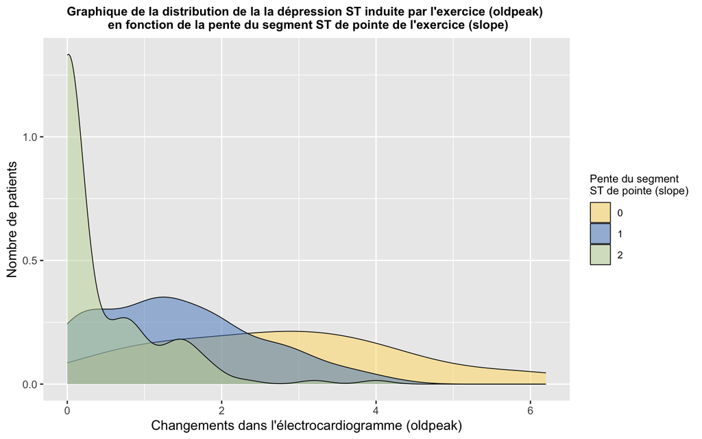

```r
# Distribution de oldpeak en fonction de slope
ggplot(df, aes(x = oldpeak, fill = factor(slope))) +
      geom_density(alpha = 0.5, # Transparence de la couleur de remplissage
                   linewidth = 0.3) + # Épaissseur des contours

      # Noms des axes et titre
      labs(title = "Graphique de la distribution de la la dépression ST induite par l'exercice (oldpeak) \n en fonction de la pente du segment ST de pointe de l'exercice (slope)", # Titre
       x = "Changements dans l'électrocardiogramme (oldpeak)", # Nom de l'axe des abscisses
       y = "Nombre de patients", # Nom de l'axe des ordonnées
       fill = "Pente du segment \nST de pointe (slope)")  + # Titre de la légende

      # Couleur et texte de la légende
      scale_fill_manual(values = c("0" = "#FFDB6D",
                                   "1" = "#4E84C4",
                                   "2" = "#C3D7A4")) +

      # Mise en forme du titre et de la légende
      theme(plot.title = element_text(hjust = 0.5, # Position du titre
                                  size = 10, # Taille du titre
                                  face = "bold"), # Titre en gras
        legend.title = element_text(size = 9), # Taille du titre de la légende
        legend.text = element_text(size = 8)) # Taille du texte de la légende
```

On remarque que lorsque la dépression ST induite par l’exercice (*oldpeak*) est proche de 0, la pente du segment ST de pointe de l’exercice (*slope*) a tendance à être de 2. Inversement, il n’y a pas de dépression du segment ST observée par rapport à la ligne de base lorsqu’il y a beaucoup de changements dans l’électrocardiogramme (ECG) qui se produisent en réponse à l’exercice physique.

On confirme donc qu’à priori, il faut enlever une des 2 variables. Dans la suite, on va faire d’autres tests pour confirmer cette décision.

On regarde ensuite plus précisement la relation entre les variables *age* et *thalach*.

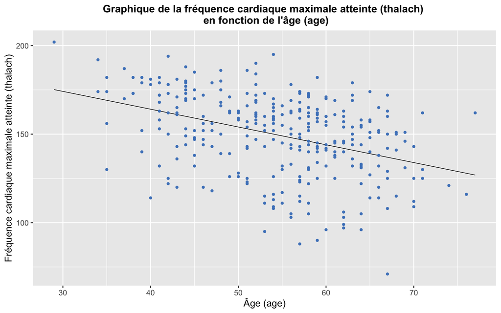

```r
# Diagramme de dispersion entre age et thalach
ggplot(df, aes(x = age, y = thalach)) +

  # Ajout de la courbe de tendance
  geom_smooth(method = "lm",
              formula = y ~ x, # Lien linéaire (polynôme de degré 1)
              se = FALSE, # Ne pas afficher l'intervalle de confiance
              colour="black", # Couleur de la droite
              linewidth = 0.3) + # Épaisseur du trait

  # Ajout des points
  geom_point(size = 1, # Taille des points
             color = "#4E84C4") + # Couleur des points

  # Nom des axes et titre
  labs(title = "Graphique de la fréquence cardiaque maximale atteinte (thalach) \n en fonction de l'âge (age)", # Titre du graphique
       x = "Âge (age)", # Nom de l'axe des abscisses
       y = "Fréquence cardiaque maximale atteinte (thalach)") + # Nom de l'axe des ordonnées

  # Mise en forme du titre et de la légende
  theme(plot.title = element_text(hjust = 0.5, # Position du titre
                                  size = 12, # Taille du titre
                                  face = "bold")) # Titre en gras
```

Cette figure fait clairement apparaître une relation décroissante et linéaire entre les deux variables. On en déduit que la fréquence cardiaque maximale diminue avec l’âge.

On étudie maintenant graphiquement le lien entre la douleur thoracique (*cp*) et la présence / l’absence d’angine de poitrine induite par l’exercice (*exang*).

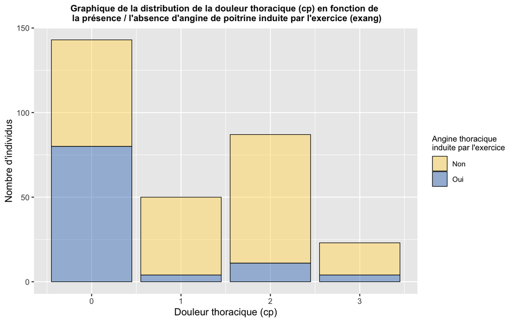

```r
# Histogramme entre cp et exang
ggplot(df, aes(x = cp, fill = factor(exang))) +
      geom_bar(color = "black", # Couleur des contours
               linewidth = 0.3, # Épaisseur des contours
               alpha = 0.5) + # Transparence de la couleur de remplissage

      # Nom des axes et titre
      labs(title = "Graphique de la distribution de la douleur thoracique (cp) en fonction de \n la présence / l'absence d'angine de poitrine induite par l'exercice (exang)", # Titre du graphique
           x = "Douleur thoracique (cp)", # Nom de l'axe des abscisses
           y = "Nombre d'individus", # Nom de l'axe des ordonnées
           fill = "Angine thoracique \ninduite par l'exercice") + # Titre de la légende

      # Texte de la légende et couleur
      scale_fill_manual(values = c("0" = "#FFDB6D", "1" = "#4E84C4"),
                        labels = c("Non", "Oui")) +

      # Mise en forme du titre et de la légende
      theme(plot.title = element_text(hjust = 0.5, # Position du titre
                                  size = 10, # Taille du titre
                                  face = "bold"), # Titre en gras
        legend.title = element_text(size = 9), # Taille du titre de la légende
        legend.text = element_text(size = 8)) # Taille du texte de la légende
```

On remarque que les individus n’ayant pas de douleur thoracique ont des angines thoraciques induites par l’exercice et inversement : les individus ayant des douleurs thoraciques n’ont pas d’angine thoracique induite par l’exercice.

La relation entre la fréquence cardiaque maximale atteinte (*thalach*) et la pente du segment ST de pointe de l’exercice (*slope*) est représentée dans le graphique ci-dessous.

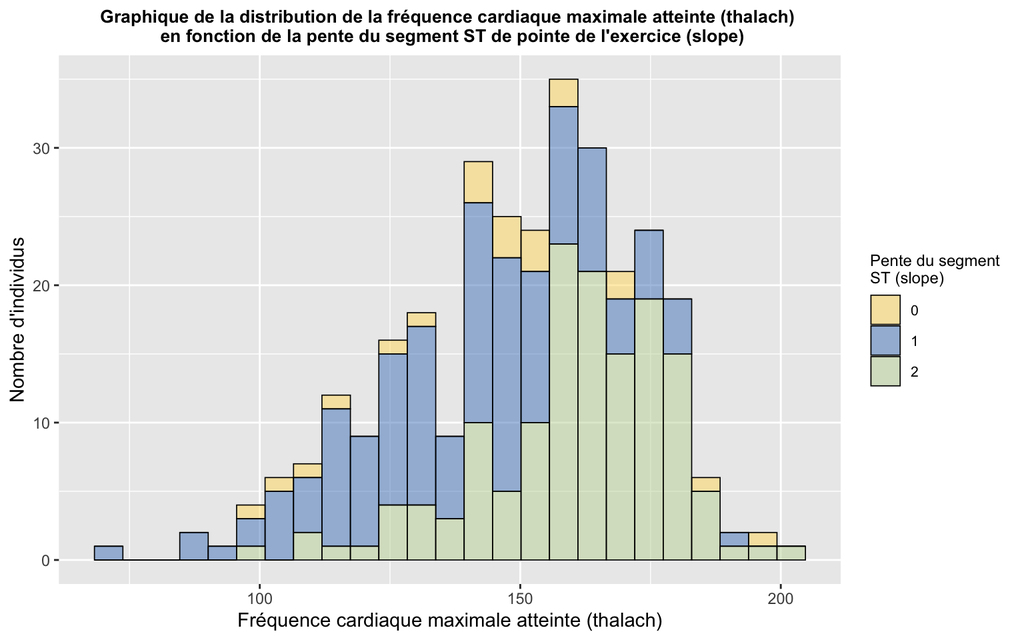

```r
# Distribution de thalach en fonction de slope
ggplot(df, aes(x = thalach, fill = factor(slope))) +
      geom_histogram(color = "black", # Couleur des contours
                     linewidth = 0.3, # Épaisseur des contours
                     bins = 25, # Nombre de catégories
                     alpha = 0.5) + # Transparence de la couleur de remplsisage

      # Nom des axes et titre
      labs(title = "Graphique de la distribution de la fréquence cardiaque maximale atteinte (thalach) \n en fonction de la pente du segment ST de pointe de l'exercice (slope)", # Titre du graphique
           x ="Fréquence cardiaque maximale atteinte (thalach)", # Nom de l'axe des abscisses
           y = "Nombre d'individus", # Nom de l'axe des ordonnées
           fill = "Pente du segment \nST (slope)") + # Titre de la légende

      # Couleur de la légende
      scale_fill_manual(values = c("0" = "#FFDB6D", "1" = "#4E84C4", "2" = "#C3D7A4")) +

      # Mise en forme du titre et de la légende
      theme(plot.title = element_text(hjust = 0.5, # Position du titre
                                  size = 10, # Taille du titre
                                  face = "bold"), # Titre en gras
        legend.title = element_text(size = 9), # Taille du titre de la légende
        legend.text = element_text(size = 8)) # Taille du texte de la légende
```

Ce graphique montre que plus la fréquence cardiaque maximale atteinte est élevée (entre 160 et 200), plus la pente du segment ST est importante (niveau 2).

Enfin, on trace la distribution de la fréquence cardiaque maximale atteinte (*thalach*) en fonction de la présence / l’absence d’angine de poitrine induite par l’exercice (*exang*) .

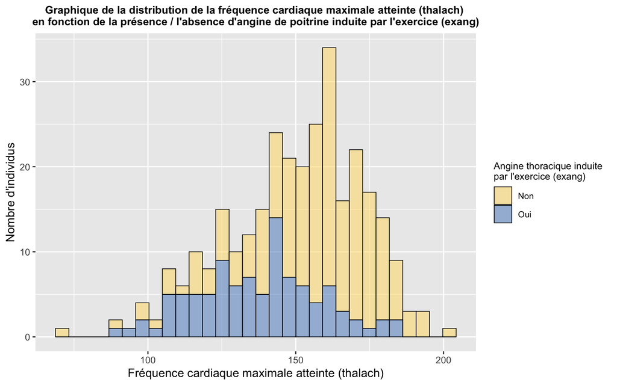

```r
# Distribution de thalach en fonction de exang
ggplot(df, aes(x = thalach, fill = factor(exang))) +
      geom_histogram(color = "black", # Couleur des contours
                     linewidth = 0.3, # Épaisseur des contours
                     bins = 30, # Nombre de catégories
                     alpha = 0.5) + # Transparence de la couleur de remplsisage

      # Noms des axes et titre
      labs(title = "Graphique de la distribution de la fréquence cardiaque maximale atteinte (thalach) \n en fonction de la présence / l'absence d'angine de poitrine induite par l'exercice (exang) ", # Titre du graphique
           x = "Fréquence cardiaque maximale atteinte (thalach)", # Nom de l'axe des abscisses
           y = "Nombre d'individus", # Nom de l'axe des orodnnées
           fill = "Angine thoracique induite \npar l'exercice (exang)") + # Titre de la légende

      # Couleur et texte de la légende
      scale_fill_manual(values = c("0" = "#FFDB6D", "1" = "#4E84C4"),
                      labels = c("Non", "Oui")) +

      # Mise en forme du titre et de la légende
      theme(plot.title = element_text(hjust = 0.5, # Position du titre
                                  size = 10, # Taille du titre
                                  face = "bold"), # Titre en gras
        legend.title = element_text(size = 9), # Taille du titre de la légende
        legend.text = element_text(size = 8)) # Taille du texte de la légende
```

On décide pour l’instant de garder les variables de chaque couple. On fera une étude plus approfondie par la suite.

### 2.4.2 Relation entre les variables explicatives et la variable cible

#### 2.4.2.1 Aperçu global

Pour avoir un aperçu global et visuel des variables qui ont un impact sur la variable cible, on affiche un graphe des coefficients de corrélation entre la variable cible et chacune des autres variables.

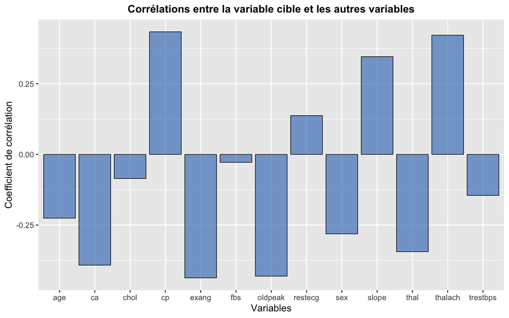

```r
# Matrice des corrélations de toutes les variables
cor_matrix <- cor(df[, 1:14])

# Récupérer les coefficients de corrélation entre la variable cible et les autres variables
target_correlations <- cor_matrix[, 14] # La 14ème colonne correspond à la variable cible

# Création d'un dataframe avec les noms des variables et leurs corrélations avec la variable cible
correlation_data <- data.frame(variable = names(target_correlations)[-14],
                               correlation = unlist(target_correlations[-14]))

# Création d'un graphique (barplot) des coefficients de corrélation
ggplot(correlation_data, aes(x = variable, y = correlation)) +
  geom_bar(stat = "identity", # Hauteur des barres = coefficient de corrélation
           fill = "#4E84C4", # Couleur de remplissage
           alpha = 0.7, # Transparence de la couleur de remplissage
           color = "black", # Couleur des contours
           linewidth = 0.3) + # Épaisseur des contours
  labs(title = 'Corrélations entre la variable cible et les autres variables', # Titre du graphique
       x = 'Variables', # Nom de l'axe des abscisses
       y = 'Coefficient de corrélation') + # Nom de l'axe des ordonnées

  theme(plot.title = element_text(hjust = 0.5, # Position du titre
                                  size = 12, # Taille du titre
                                  face = "bold")) # Titre en gras
```

#### 2.4.2.2 Relation entre les variables catégorielles et la variable cible

On va maintenant regarder plus précisemment les relations entre les variables explicatives et la target. On commence par étudier les variables catégorielles puis on étudiera les variables numériques.

Grâce à l’aperçu global, on a vu que seules les variables catégorielles *sex, cp, exang, slope, ca* et *thal* avaient potentiellement une relation avec la variable cible. On affiche alors un histogramme de chacune de ces variables en fonction de la target pour voir graphiquement cette relation.

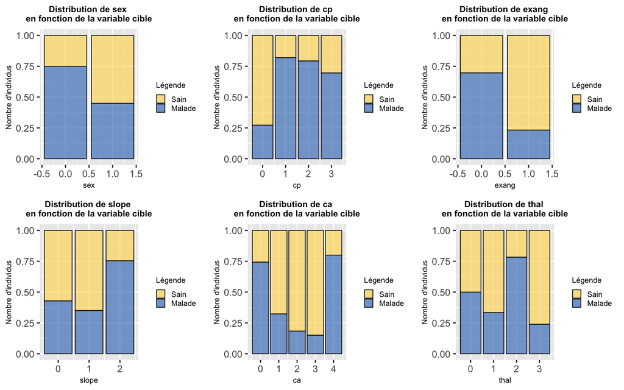

```r
# Création d'un vecteur avec les variables catégorielles qui semblent avoir un impact sur la variable cible
categorical_var_impact <- c("sex", "cp", "exang", "slope", "ca", "thal")

# Création d'une liste pour stocker les graphiques
hist <- list()

# Boucle qui crée un histogramme pour chaque variable du vecteur categorical_var_impactet et qui l'affiche
for (var in categorical_var_impact) {
    h <- ggplot(df, aes(x = .data[[var]], fill = factor(target))) +
      geom_bar(color = "black", # Couleur des contours
               linewidth = 0.3, # Épaisseur des contours
               position = "fill", # Représenter des proportions
               alpha = 0.7) + # Transparence de la couleur de remplissage

      # Noms des axes et titre
      labs(title = paste("Distribution de", var, "\nen fonction de la variable cible"), # Titre des graphiques
           x = var, # Nom de l'axe des abscisses
           y = "Nombre d'individus", # Nom de l'axe des ordonnées
           fill = "Légende") + # Titre de la légende

      # Couleur et texte de la légende
      scale_fill_manual(values = c("0" = "#FFDB6D", "1" = "#4E84C4"),
                      labels = c("Sain", "Malade")) +

      # Mise en forme du titre et de la légende
      theme(plot.title = element_text(hjust = 0.5, # Position du titre
                                  size = 8, # Taille du titre
                                  face = "bold"), # Titre en gras
        legend.title = element_text(size = 7), # Taille du titre de la légende
        legend.text = element_text(size = 7), # Taille du texte de la légende
        legend.key.size = unit(0.3, "cm"), # Taille des carrés de couleur de la légende
        axis.title.x = element_text(size = 7), # Taille du nom de l'axe des abscisses
        axis.title.y = element_text(size = 7))  # Taille du nom de l'axe des ordonnée

    hist[[var]] <- h
}

# Organisation des graphiques dans une grille à 3 colonnes
grid.arrange(grobs = hist, ncol = 3)
```

On peut observer sur ces graphiques que les variables catégorielles selectionnées semblent effectivement avoir un impact sur la variable cible. En effet, les individus qui semblent plus enclin à avoir une maladie cardiaque sont :

**Remarque** : des précisions sur les observations et conclusions étonnantes seront apportées dans la conclusion.

#### 2.4.2.3 Relation entre les variables numériques et la variable cible

Enfin, grâce à l’aperçu global, on a vu que seules les variables numériques *thalach* et *oldpeak* avaient potentiellement une relation avec la variable cible. On affiche alors la densité de chacune de ces variables en fonction de la target pour voir graphiquement cette relation.

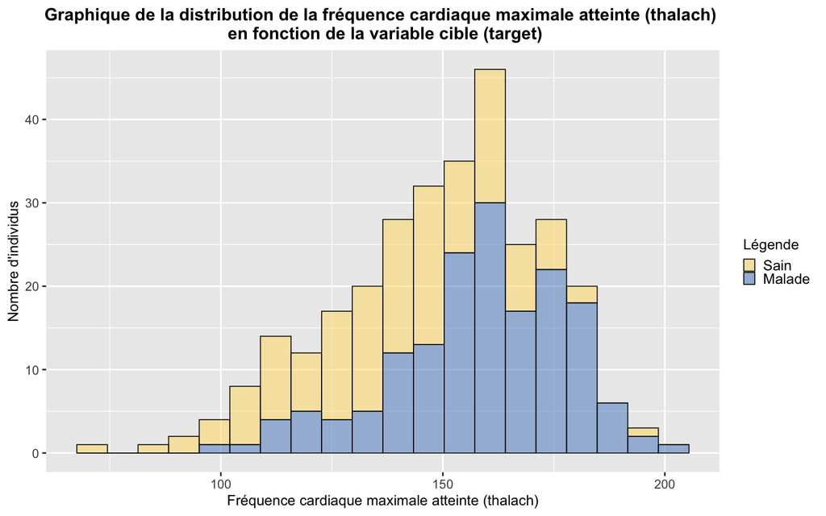

```r
# Graphique de target en fonction de thalach

ggplot(df, aes(x = thalach, fill = factor(target))) +
      geom_histogram(color = "black", # Couleur des contours
                     linewidth = 0.3, # Épaisseur des contours
                     bins = 20, # 20 classes pour plus de lisibilité
                     alpha = 0.5) + # Transparence de la couleur de remplissage

      # Noms des axes et titre
      labs(title = "Graphique de la distribution de la fréquence cardiaque maximale atteinte (thalach) \n en fonction de la variable cible (target)", # Titre du grahique
           x = "Fréquence cardiaque maximale atteinte (thalach)", # Nom de l'axe des abscisses
           y = "Nombre d'individus", # Nom de l'axe des ordonnées
           fill = "Légende") + # Nom du titre de la légende

      # Couleur et texte de la légende
      scale_fill_manual(values = c("0" = "#FFDB6D", "1" = "#4E84C4"),
                        labels = c("Sain", "Malade")) +

      # Mise en forme du titre et de la légende
      theme(plot.title = element_text(hjust = 0.5, # Position du titre
                                  size = 12, # Taille du titre
                                  face = "bold"), # Titre en gras
        legend.title = element_text(size = 10), # Taille du titre de la légende
        legend.text = element_text(size = 10), # Taille du texte de la légende
        legend.key.size = unit(0.3, "cm"), # Taille des carrés de couleur de la légende
        axis.title.x = element_text(size = 10), # Taille du nom de l'axe des abscisses
        axis.title.y = element_text(size = 10))  # Taille du nom de l'axe des ordonnée
```

On peut observer sur ce graphique que la variable *thalach* semble effectivement avoir un impact sur la variable cible. En effet, les individus qui semblent plus enclin à avoir une maladie cardiaque sont les individus ayant une fréquence cardiaque maximale entre 150 et 200 bpm.

Enfin, on trace ci-dessous la distribution de la la dépression ST induite par l’exercice (oldpeak) en fonction de la variable cible.

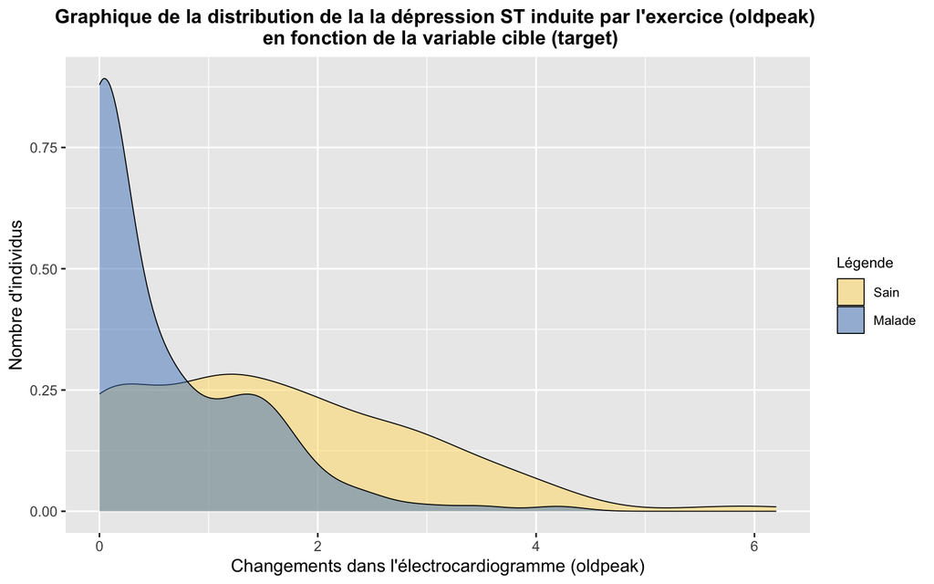

```r
# Distribution de oldpeak en fonction de target
ggplot(df, aes(x = oldpeak, fill = factor(target))) +
      geom_density(alpha = 0.5, # Transparence de la couleur de remplissage
                   linewidth = 0.3) + # Épaisseur des contours

      # Noms des axes et titre
      labs(title = "Graphique de la distribution de la la dépression ST induite par l'exercice (oldpeak) \n en fonction de la variable cible (target)", # Titre du graphique
       x = "Changements dans l'électrocardiogramme (oldpeak)", # Nom de l'axe des abscisses
       y = "Nombre d'individus", # Nom de l'axe des ordonnées
       fill = "Légende")  + # Nom du titre de la légende

      # Couleur et texte de la légende
      scale_fill_manual(values = c("0" = "#FFDB6D", "1" = "#4E84C4"),
                      labels = c("Sain", "Malade")) +

      # Mise en forme du titre et de la légende
      theme(plot.title = element_text(hjust = 0.5, # Position du titre
                                  size = 12, # Taille du titre
                                  face = "bold"), # Titre en gras
        legend.title = element_text(size = 9), # Taille du titre de la légende
        legend.text = element_text(size = 8)) # Taille du texte de la légende
```

On conclut que les individus n’ayant pas de changement dans l’electrocardiogramme ont plus tendance à avoir une maladie cardiaque et inversement.

## 2.5 Sampling : division du jeu de données

On divise le jeu de données en 2 ensembles :

- un ensemble d’entrainement qui va permettre de construire le modèle,
- un ensemble de test pour évaluer les performances du modèle.

On choisit une porportion souvent utilisée pour un jeu de données de petite taille : 80% des données sont utilisées pour former l’ensemble d’entrainement et 20% pour celui de test. On affiche ci-dessous les dimensions des deux ensembles et celles du jeu de données de base.

```r
# Division des données en ensembles d'entraînement et de test
set.seed(123) # pour la reproductibilité
split <- rsample::initial_split(df, prop = 0.8)
train <- rsample::training(split)
test <- rsample::testing(split)

# Création d'un dataframe avec les dimensions des différents ensembles
dimensions <- data.frame(dim(df), dim(train), dim(test))
rownames(dimensions) <- row_names <- c("Nombre de lignes",
                                       "Nombre de colonnes") # nom des lignes
colnames(dimensions) <- c("Dimension du jeu de données initial",
                          "Dimensions de l'ensemble d'entrainement",
                          "Dimensions de l'ensemble de test") # nom des colonnes

# Affichage des dimensions des ensembles d'entraînement et de test
dimensions %>%
  kbl() %>%
  kable_styling()
```

|  | Dimension du jeu de données initial | Dimensions de l’ensemble d’entrainement | Dimensions de l’ensemble de test |
| --- | --- | --- | --- |
| Nombre de lignes | 303 | 242 | 61 |
| Nombre de colonnes | 14 | 14 | 14 |

On regarde la distribution de la variable cible dans les 2 ensembles pour s’assurer que la répartition des classes dans l’ensemble de test et d’entrainement est représentative de l’ensemble complet.

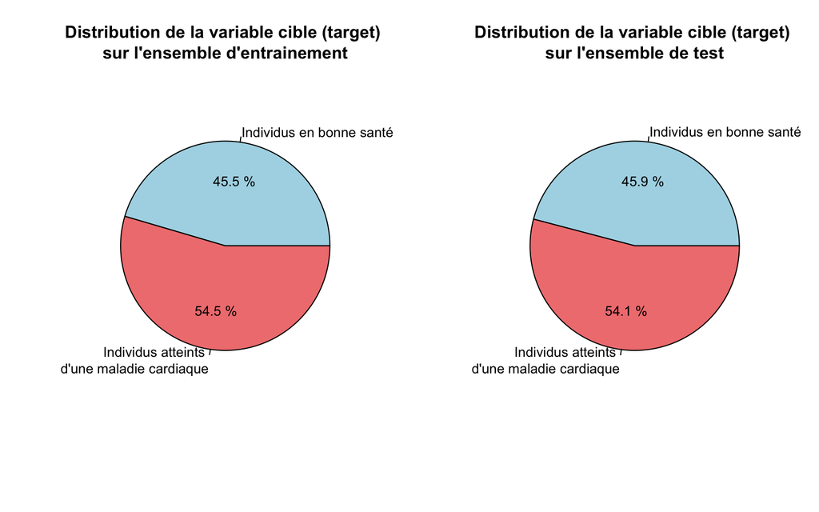

```r
# Organisation des graphiques en une grille 1x2
par(mfrow = c(1, 2))

# Création du camembert pour l'ensemble train avec les pourcentages et légendes
pie(table(train$target), #  Table des effectifs pour la variable target
    main = "Distribution de la variable cible (target) \nsur l'ensemble d'entrainement", # Titre
    labels = c("Individus en bonne santé",
               "Individus atteints \nd'une maladie cardiaque"), # Légende
    col = c("lightblue", "lightcoral"), # Définition de la couleur des secteurs
    cex = 0.8, # Ajustement de la taille de la légende
    cex.main = 1) # Ajustement de la taille du titre

# Ajout des étiquettes
percent_values_train <- round(100 * prop.table(table(train$target)), 1) # Calcul des pourcentages arrondis
percent_train <- paste(percent_values_train, "%") # Ajout su sigle "%"
text_pie(percent_values_train,  c(percent_train[1], percent_train[2]), cex=0.8) # Utilisation de la fonction text_pie définie plus haut


# Création du camembert pour l'ensemble test avec les pourcentages et légendes
pie(table(test$target), #  Table des effectifs pour la variable target
    main = "Distribution de la variable cible (target) \nsur l'ensemble de test", # Titre
    labels = c("Individus en bonne santé",
               "Individus atteints \nd'une maladie cardiaque"), # Légende
    col = c("lightblue", "lightcoral"), # Définition de la couleur des secteurs
    cex = 0.8, # Ajustement de la taille de la légende
    cex.main = 1) # Ajustement de la taille du titre

# Ajout des étiquettes
percent_values_test <- round(100 * prop.table(table(test$target)), 1) # Calcul des pourcentages arrondis
percent_test <- paste(percent_values_test, "%") # Ajout su sigle "%"
text_pie(percent_values_test,  c(percent_test[1], percent_test[2]), cex=0.8) # Utilisation de la fonction text_pie définie plus haut
```

# 3 Fitting : création et entraînement du modèle

## 3.1 Déclaration du modèle

On implémente maintenant une régression logistique à l’aide de la fonction “glm”. On pourra trouver une explication du choix du modèle dans la notice. On déclare aussi le modèle réduit à l’intercept car il sera utile dans la suite, pour des comparaisons de perfromance par exemple.

```r
# Déclaration du modèle de regression logistique
mod <- glm(target ~ ., data = train, family = binomial)

# Déclaration du modèle réduit à l'intercept (utile dans la suite)
mod_int <- glm(target~1, data = train, family = "binomial")
```

On affiche les statistqiues récapitulatives du modèle de regression logistique construit dans la sous-section section précédente. Les p-valeurs inférieures à 0.05 sont affichées en rouge car cela signifie que la variable associée à probablement de l’importance dans le modèle.

```r
# Création d'un tableau qui contient les coefficients du modèle
tab_stat <- tidy(mod, conf.int = TRUE)

# Mise en forme de la colonne p.value pour afficher en rouge les les p-valeurs inférieures à 0.05
tab_stat <- tab_stat %>%
  mutate(p.value = ifelse(p.value < 0.05,
                                    cell_spec(round(p.value, 3), "html", color = "red"),
                                    cell_spec(round(p.value, 3), "html")))

# Affichage du tableau avec mise en forme
tab_stat %>%
  kbl(digits = c(0, 2, 2, 2, 5, 3, 3), # Arrondis
      escape = FALSE,
      caption = "Statistiques récapitulatives du modèle de regression logistique") %>%
  kable_styling()
```

Table 3.1: Statistiques récapitulatives du modèle de regression logistique

| term | estimate | std.error | statistic | p.value | conf.low | conf.high |
| --- | --- | --- | --- | --- | --- | --- |
| (Intercept) | 4.56 | 2.79 | 1.63 | 0.103 | -0.824 | 10.204 |
| age | -0.01 | 0.03 | -0.53 | 0.599 | -0.063 | 0.036 |
| sex | -1.54 | 0.51 | -3.02 | 0.003 | -2.590 | -0.578 |
| cp | 0.77 | 0.20 | 3.94 | 0 | 0.398 | 1.169 |
| trestbps | -0.02 | 0.01 | -1.63 | 0.103 | -0.040 | 0.003 |
| chol | 0.00 | 0.00 | -0.76 | 0.446 | -0.011 | 0.005 |
| fbs | 0.13 | 0.57 | 0.23 | 0.815 | -0.962 | 1.270 |
| restecg | 0.66 | 0.39 | 1.69 | 0.09 | -0.101 | 1.434 |
| thalach | 0.02 | 0.01 | 1.73 | 0.084 | -0.002 | 0.043 |
| exang | -1.08 | 0.45 | -2.40 | 0.016 | -1.969 | -0.199 |
| oldpeak | -0.68 | 0.24 | -2.82 | 0.005 | -1.176 | -0.224 |
| slope | 0.26 | 0.41 | 0.64 | 0.522 | -0.563 | 1.065 |
| ca | -0.65 | 0.20 | -3.21 | 0.001 | -1.050 | -0.254 |
| thal | -1.02 | 0.33 | -3.08 | 0.002 | -1.684 | -0.382 |

D’après cet affichage, les variables qui ont une importance sont : *sex, cp, exang, oldpeak, ca* et *thal*.

On peut noter que la déviance du modèle est inférieure à celle du modèle réduit à l’intercept :

```r
# Création d'un dataframe avec les déviances
deviance <- data.frame(mod$null.deviance, mod$deviance)
colnames(deviance) <- c("Déviance du modèle réduit à l'intercept",
                          "Déviance du modèle créé") # Nom des colonnes

# Affichage des dimensions des ensembles d'entraînement et de test
deviance %>%
  kbl(digits = c(2, 2), # Arrondis
      caption = "Déviance des modèles") %>%
  kable_styling()
```

Table 3.2: Déviance des modèles

| Déviance du modèle réduit à l’intercept | Déviance du modèle créé |
| --- | --- |
| 333.48 | 173.07 |

Le modèle est donc meilleur que le modèle réduit à l’inetrcept.

## 3.2 Sélection de modèles : tests et méthodes pas à pas

On utilise le test Anova pour enlever les variables qui n’apportent pas d’informations complémentaires sur la variable à prédire. On affiche le résultat du test. Les p-valeurs inférieurs à 0.05 sont affichées en rouge.

```r
# Test Anova
Ano <- Anova(mod,
             type = 3, #  type III de l'Anova
             test.statistic = "LR") # test de rapport de vraisemblance

# Création d'un tableau qui contient les coefficients du modèle
tab_stat <- tidy(Ano, conf.int = TRUE)

# Mise en forme de la colonne p.value pour afficher en rouge les les p-valeurs inférieures à 0.05
tab_stat <- tab_stat %>%
  mutate(p.value = ifelse(p.value < 0.05,
                                    cell_spec(round(p.value, 3), "html", color = "red"),
                                    cell_spec(round(p.value, 3), "html")))

# Affichage du tableau avec mise en forme
tab_stat %>%
  kbl(digits = c(0, 3, 5),
      escape = FALSE,
      caption = "Résultats du test Anva") %>%
  kable_styling()
```

Table 3.3: Résultats du test Anva

| term | statistic | df | p.value |
| --- | --- | --- | --- |
| age | 0.276 | 1 | 0.599 |
| sex | 10.168 | 1 | 0.001 |
| cp | 17.275 | 1 | 0 |
| trestbps | 2.732 | 1 | 0.098 |
| chol | 0.571 | 1 | 0.45 |
| fbs | 0.055 | 1 | 0.814 |
| restecg | 2.892 | 1 | 0.089 |
| thalach | 3.069 | 1 | 0.08 |
| exang | 5.758 | 1 | 0.016 |
| oldpeak | 8.806 | 1 | 0.003 |
| slope | 0.405 | 1 | 0.524 |
| ca | 10.405 | 1 | 0.001 |
| thal | 9.976 | 1 | 0.002 |

Seules les variables *sex, cp, exang, oldpeak, ca* et *thal* semblent avoir un impact sur la variable cible, ce qu’on avait déjà observé dans la partie “graphiques”. On avait aussi remarqué que les variables *exang, slope* et *age* avaient une importance. On va continuer notre étude pour savoir si on les supprime ou non.

On effectue maintenent des méthodes pas à pas pour sélectionner un modèle à l’aide d’une procédure basée sur la minimisation du critère AIC (Akaike Information Criterion).

On réalise d’abord une méthode *backward* et on affiche les statistqiues descriptives du modèle obtenu. Les p_valeurs inférieures à 0.05 sont affichées en rouge.

```r
# Méthode backward
mod_back <- step(mod, direction = "backward", trace = FALSE)

# Création d'un tableau qui contient les coefficients du modèle
tab_stat <- tidy(mod_back, conf.int = TRUE)

# Mise en forme de la colonne p.value pour afficher en rouge les les p-valeurs inférieures à 0.05
tab_stat <- tab_stat %>%
  mutate(p.value = ifelse(p.value < 0.05,
                                    cell_spec(round(p.value, 3), "html", color = "red"),
                                    cell_spec(round(p.value, 3), "html")))

# Affichage du tableau avec mise en forme
tab_stat %>%
  kbl(digits = c(0, 3, 3, 3, 4), # Arrondis
      escape = FALSE,
      caption = "Statistiques récapitulatives du modèle construit par la méthode backward") %>%
  kable_styling()
```

Table 3.4: Statistiques récapitulatives du modèle construit par la méthode backward

| term | estimate | std.error | statistic | p.value | conf.low | conf.high |
| --- | --- | --- | --- | --- | --- | --- |
| (Intercept) | 3.196 | 2.194 | 1.457 | 0.145 | -1 | 7.644 |
| sex | -1.326 | 0.461 | -2.878 | 0.004 | -2 | -0.452 |
| cp | 0.771 | 0.194 | 3.967 | 0 | 0 | 1.168 |
| trestbps | -0.019 | 0.011 | -1.837 | 0.066 | 0 | 0.001 |
| restecg | 0.766 | 0.379 | 2.023 | 0.043 | 0 | 1.522 |
| thalach | 0.022 | 0.010 | 2.164 | 0.03 | 0 | 0.043 |
| exang | -1.067 | 0.442 | -2.415 | 0.016 | -2 | -0.201 |
| oldpeak | -0.762 | 0.211 | -3.613 | 0 | -1 | -0.368 |
| ca | -0.629 | 0.192 | -3.282 | 0.001 | -1 | -0.258 |
| thal | -1.057 | 0.329 | -3.211 | 0.001 | -2 | -0.427 |

Les variables importantes sont celles du test Anova ainsi que *restecg* et *thalach*.

On réalise maintenant une méthode *forward* de sélection de modèle et on affiche là encore, les statistqiues descriptives du modèle obtenu. Les p_valeurs inférieures à 0.05 sont affichées en rouge.

```r
# Méthode forward
mod_for <- step(mod_int,
                target ~ age + sex + trestbps + chol + fbs + restecg + thalach
                 + exang + oldpeak + slope + ca + thal,
                data = train,
                trace = FALSE,
                direction = c("forward"))

# Création d'un tableau qui contient les coefficients du modèle
tab_stat <- tidy(mod_for, conf.int = TRUE)

# Mise en forme de la colonne p.value pour afficher en rouge les les p-valeurs inférieures à 0.05
tab_stat <- tab_stat %>%
  mutate(p.value = ifelse(p.value < 0.05,
                                    cell_spec(round(p.value, 3), "html", color = "red"),
                                    cell_spec(round(p.value, 3), "html")))

# Affichage du tableau avec mise en forme
tab_stat %>%
  kbl(digits = c(0, 3, 3, 3, 4), # Arrondis
      escape = FALSE,
      caption = "Statistiques récapitulatives du modèle construit par la méthode forward") %>%
  kable_styling()
```

Table 3.5: Statistiques récapitulatives du modèle construit par la méthode forward

| term | estimate | std.error | statistic | p.value | conf.low | conf.high |
| --- | --- | --- | --- | --- | --- | --- |
| (Intercept) | 0.706 | 1.607 | 0.439 | 0.661 | -2 | 3.875 |
| oldpeak | -0.634 | 0.187 | -3.398 | 0.001 | -1 | -0.283 |
| exang | -1.531 | 0.404 | -3.789 | 0 | -2 | -0.753 |
| ca | -0.668 | 0.179 | -3.742 | 0 | -1 | -0.326 |
| thal | -1.020 | 0.305 | -3.345 | 0.001 | -2 | -0.434 |
| thalach | 0.026 | 0.009 | 2.740 | 0.006 | 0 | 0.044 |
| sex | -1.029 | 0.411 | -2.504 | 0.012 | -2 | -0.238 |
| restecg | 0.784 | 0.350 | 2.240 | 0.025 | 0 | 1.482 |

On réalise une dernière méthode : la méthode *both* en affichant toujours les statistqiues descriptives du modèle obtenu. Les p_valeurs inférieures à 0.05 sont affichées en rouge.

```r
# Méthode both
mod_both <- step(mod_int,
                 target ~ age + sex + trestbps + chol + fbs + restecg + thalach
                 + exang + oldpeak + slope + ca + thal,
                 data = train,
                 trace = F,
                 direction = c("both"))

# Création d'un tableau qui contient les coefficients du modèle
tab_stat <- tidy(mod_both, conf.int = TRUE)

# Mise en forme de la colonne p.value pour afficher en rouge les les p-valeurs inférieures à 0.05
tab_stat <- tab_stat %>%
  mutate(p.value = ifelse(p.value < 0.05,
                                    cell_spec(round(p.value, 3), "html", color = "red"),
                                    cell_spec(round(p.value, 3), "html")))

# Affichage du tableau avec mise en forme
tab_stat %>%
  kbl(digits = c(0, 3, 3, 3, 4), # Arrondis
      escape = FALSE,
      caption = "Statistiques récapitulatives du modèle construit par la méthode both") %>%
  kable_styling()
```

Table 3.6: Statistiques récapitulatives du modèle construit par la méthode both

| term | estimate | std.error | statistic | p.value | conf.low | conf.high |
| --- | --- | --- | --- | --- | --- | --- |
| (Intercept) | 0.706 | 1.607 | 0.439 | 0.661 | -2 | 3.875 |
| oldpeak | -0.634 | 0.187 | -3.398 | 0.001 | -1 | -0.283 |
| exang | -1.531 | 0.404 | -3.789 | 0 | -2 | -0.753 |
| ca | -0.668 | 0.179 | -3.742 | 0 | -1 | -0.326 |
| thal | -1.020 | 0.305 | -3.345 | 0.001 | -2 | -0.434 |
| thalach | 0.026 | 0.009 | 2.740 | 0.006 | 0 | 0.044 |
| sex | -1.029 | 0.411 | -2.504 | 0.012 | -2 | -0.238 |
| restecg | 0.784 | 0.350 | 2.240 | 0.025 | 0 | 1.482 |

Le modèle garde les mêmes variables que celles obtenues avec la méthode *forward*.

Enfin, on compare l’AIC des modèles obtenus par les 3 méthodes.

```r
# Création d'un dataframe avec les AIC
deviance <- data.frame(AIC(mod_back), AIC(mod_for), AIC(mod_both))
colnames(deviance) <- c("Méthode backward",
                        "Méthode forward",
                        "Méthode both") # Nom des colonnes

# Affichage des AIC des modèles
deviance %>%
  kbl(digits = c(1, 1, 1), # pour les arrondis
      caption = "AIC des modèles") %>% # Titre du tableau
  kable_styling()
```

Table 3.7: AIC des modèles

| Méthode backward | Méthode forward | Méthode both |
| --- | --- | --- |
| 194.5 | 209.6 | 209.6 |

## 3.3 Construction du modèle final

```r
# Construction du modèle final
mod_final <- glm(target ~ sex + exang + oldpeak + ca + thal + restecg + thalach + cp,
                 data = train,
                 family = "binomial")
```

# 4 Validation du modèle

Après avoir obtenu un modèle, il faut diagnostiquer la régression afin de valider ou non le modèle. On passe alors à la validation de notre modèle ainsi construit. On regarde dans un premier temps la déviance du modèle puis on étudie les résidus et les *outliers*.

## 4.1 Déviance

```r
# Création d'un dataframe avec les déviances
deviance <- data.frame(mod$null.deviance, mod_final$deviance)
colnames(deviance) <- c("Déviance du modèle réduit à l'intercept",
                        "Déviance du modèle final") # nom des colonnes

# Affichage des dimensions des ensembles d'entraînement et de test
deviance %>%
  kbl(digits = c(2, 2), caption = "Déviance des modèles") %>% # pour les arrondis
  kable_styling()
```

Table 4.1: Déviance des modèles

| Déviance du modèle réduit à l’intercept | Déviance du modèle final |
| --- | --- |
| 333.48 | 178.01 |

La déviance de notre modèle étant plus petite que celle du modèle réduit à l’intercept, on le privilegie.

## 4.2 Résidus studentisés

On affiche ci-dessous un nuage de points montrant les résidus studentisés du modèle final pour chaque observation. On a aussi tracé sur ce même graphe des lignes de seuil pour repérer les observations ayant des résidus considérés comme atypiques en dehors de ces bornes.

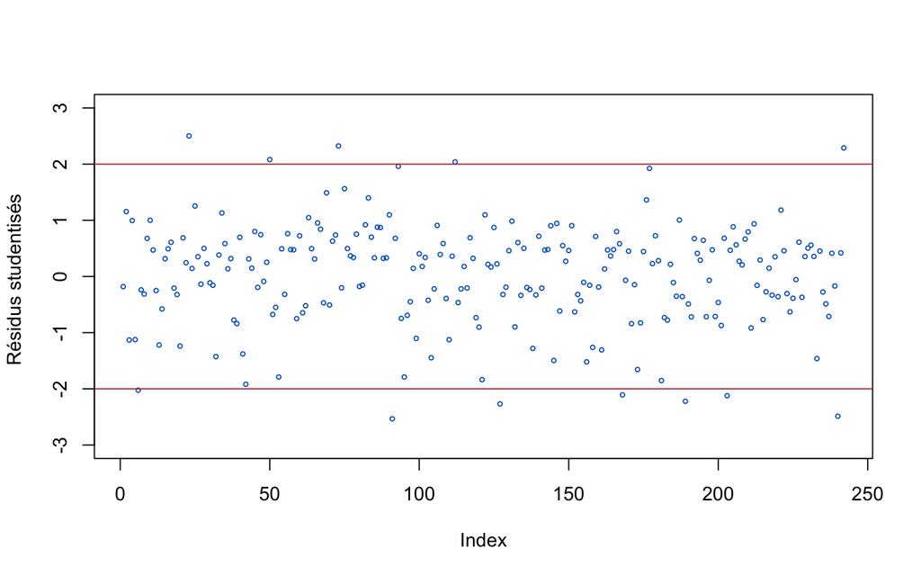

```r
par(mfrow = c(1, 1))
plot(rstudent(mod_final), type = "p", cex = 0.5, ylab = "Résidus studentisés ",
    col = "#0066CC", ylim = c(-3, 3))
abline(h = c(-2, 2), col = "#CC3333")
```

On remarque que les résidus suivent un schéma aléatoire, ce qui valide le modèle. Les quelques points au-delà des lignes rouges sont les valeurs atypiques que nous avions déjà remarqué dans les boxplots. Nous avions décidé de garder ces valeurs.

## 4.3 Outliers

Enfin, on affiche le graphe des *outliers*.

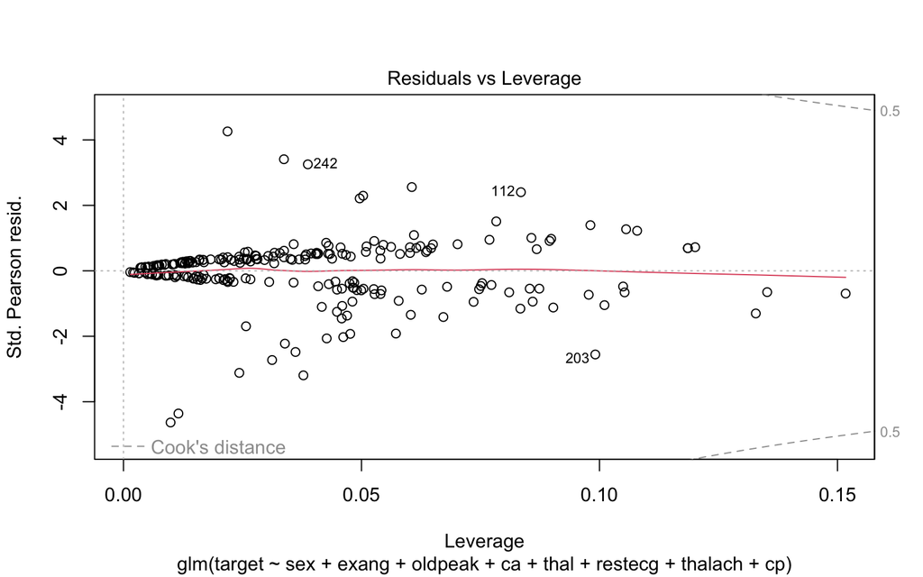

```r
# Plot des outliers
plot(mod_final,5)
```

Il ne semble pas y avoir d’outliers car aucun point n’a une distance de Cook supérieure à 1.

# 5 Optimisation du seuil de décision

On va maintenant optimsier le seuil à partir duquel on considère qu’un individu à une maladie cardiaque. Dans notre cas, on préfère naturellemnt avoir un petit nombre de faux négatifs (FN) c’est-à-dire un petit nombre de personnes qui n’ont pas été diagnostiquées comme positives alors qu’elles ont une maladie cardiaque.

Pour optimiser le seuil, on va donc maximsier l’indice de Youden qui est un critère couramment utilisé pour minimiser le nombre de faux négatif.

On affiche ici un graphe qui montre l’évolution de l’indice de Youden en fonction des seuils. On affiche sur ce même graphe le seuil optimal qui maximise cet indice.

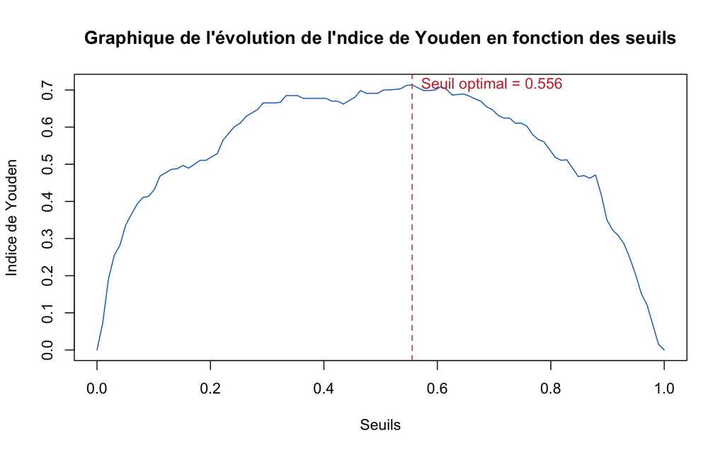

```r
# Calcul des valeurs de seuil
val_seuil <- seq(0, 1, length.out = 100)

# Calcul de l'indice de Youden pour chaque seuil
youden_index <- sapply(val_seuil, function(threshold) {
  pred_pos <- predicted_probs_train > threshold
  sens <- sum(pred_pos & (train$target == 1)) / sum(train$target == 1)
  spec <- sum(!pred_pos & (train$target == 0)) / sum(train$target == 0)
  return(sens + spec - 1)
})

# Trouver le seuil optimal
optimal <- val_seuil[which.max(youden_index)]

# Créer le graphique de l'indice de Youden en fonction des seuils
plot(val_seuil,
     youden_index,
     type = "l",
     col = "#0066CC", # Couleur de la courbe
     xlab = "Seuils", # Nom de l'axe des abscisses
     ylab = "Indice de Youden",# Nom de l'axe des ordonnées
     main = "Graphique de l'évolution de l'ndice de Youden en fonction des seuils") # Titre du graphique

# Afficher le seuil optimal
abline(v = optimal,
       col = "#CC3333", # Couleur de la droite
       lty = 2) # Épaisseur de la droite

# Afficher la légende
text(optimal,
     max(youden_index),
     paste("Seuil optimal =", round(optimal, 3)),
     pos = 4,
     col = "#CC3333")
```

Le seuil qui maximise l’indice de Youden vaut 0.556. On va donc garder ce seuil et prédire à patir de celui-ci. On affiche ci-dessous l’évolution de la sensibilité et de la spécificité en fonction de la valeur du seuil. On affiche sur ce même-graphique la valeur du seuil optimal.

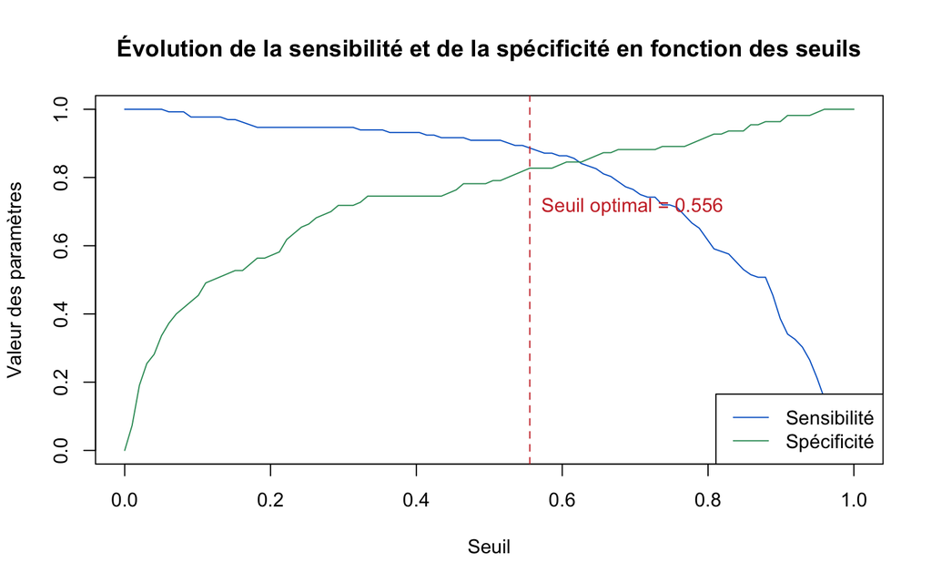

```r
# Initialisation des vecteurs de sensibilité et spécificité
sensitivities <- c()
specificities <- c()

for (threshold in val_seuil) {
  pred_pos <- predicted_probs_train > threshold
  sens <- sum(pred_pos & (train$target == 1)) / sum(train$target == 1)
  spec <- sum(!pred_pos & (train$target == 0)) / sum(train$target == 0)

  sensitivities <- c(sensitivities, sens)
  specificities <- c(specificities, spec)
}

# Création du graphique avec la courbe de l'évolution de la sensibilité
plot(val_seuil,
     sensitivities,
     type = "l",
     col = "#0066CC", # Couleur de la courbe
     xlab = "Seuil", # Nom de l'axe des abscisses
     ylab = "Valeur des paramètres", # Nom de l'axe des ordonnées
     main = "Évolution de la sensibilité et de la spécificité en fonction des seuils") # Titre du graphique

# Ajout de la courbe de l'évolution de la spécificité
lines(val_seuil,
      specificities,
      type = "l",
      col = "#339966") # Couleur de la droite

# Ajout de la légende
legend("bottomright",
       legend = c("Sensibilité", "Spécificité"),
       col = c("#0066CC", "#339966"),
       lty = 1)

# Ajout de la valeur du seuil optimal
abline(v = optimal,
       col = "#CC3333",
       lty = 2)

# Ajout de texte
text(optimal,
     max(youden_index),
     paste("Seuil optimal =", round(optimal, 3)),
     pos = 4,
     col = "#CC3333")
```

On remarque donc que la valeur optimale pour l’indice de Youden ne l’est pas pour la sensibilité ni la spécificité. Cela est du au fait qu’on a du faire un choix en selectionnant un indicateur à optimiser parmi plusieurs autres, ici, le nombre de faux négatifs. Cependant, au seuil optimal, la spécificité et la sensibilité sont satisfaisantes. On garde donc ce seuil.

# 6 Prédiction et performances

## 6.1 Prédiction

On passe maintenant à la prédiction. On prédit de telle manière que si la probabilité prédite dépasse le seuil optimal, l’individu est considéré comme étant susceptible de développer une maladie cardiaque.

On affiche ci-dessous les prédictions à côté des valeurs réelles dans un tableau.

```r
# Création d'un dataframe avec les observations et les prédictions
df_pred <- data.frame(Observed = test$target, Predicted = predicted)
rmarkdown::paged_table(df_pred)
```

|  | Observed | Predicted |
| --- | --- | --- |
| 1 | 1 | 1 |
| 2 | 1 | 1 |
| 3 | 1 | 1 |
| 4 | 1 | 1 |
| 5 | 1 | 1 |
| 6 | 1 | 1 |
| 7 | 1 | 0 |
| 8 | 1 | 1 |
| 9 | 1 | 1 |
| 10 | 1 | 1 |

[output cut: 51 more lines]

## 6.2 Matrice de confusion

Pour étudier les performances de prédiction, on affiche la matrice de confusion qui permet d’observer le nombre de vrais positifs, de faux positifs, de vrais négatifs et de faux négatifs.

[figure not shown]

```r
# Création de la matrice de confusion
confusion_matrix <- table(factor(predicted), factor(test$target))
# Affichage de la matrice de confusion
par(mfrow=c(1, 1))
ctable <- as.table(confusion_matrix,
                   nrow = 2,
                   byrow = TRUE)
# Définir les étiquettes "malade" et "sain" pour les lignes et colonnes
rownames(ctable) <- colnames(ctable) <- c("malade (1)", "sain (0)")

# Définir les étiquettes "Réel" et "Prédit"
dimnames(ctable) <- list(Réel = rownames(ctable), Prédit = colnames(ctable))

fourfoldplot(ctable,
             color = c("#CC6666", "#CCCCCC"),
             conf.level = 0,
             margin = 1,
             main = "Matrice de confusion \ndu modèle de regression logistique")
```

## 6.3 Indicateurs et métriques de performance

La sensibilité, le F1 Score et la valeur prédictive négative sont des indicateurs importants pour évaluer la capacité du modèle à minimiser les faux négatifs, chacun apportant une compréhension particulière sur cette problématique. On s’intéresse donc ici plus particulièrement à ces indicateurs ainsi que l’accuracy (la précision globale).

```r
# Créer des facteurs avec des niveaux correspondants
predicted_factor <- factor(as.numeric(predicted), levels = c(0, 1))
test_target_factor <- factor(as.numeric(test$target), levels = c(0, 1))

# Simulation de la sortie confusionMatrix
results <- confusionMatrix(predicted_factor, test_target_factor, mode = "everything", positive = "1")

# Extraction de l'accuracy
acc <- data.frame(Valeur = results$overall["Accuracy"])

# Extraction des valeurs spécifiques
specific_metrics <- c("Sensitivity", "Neg Pred Value", "F1")
specific_values <- unlist(results$byClass[specific_metrics])

# Création du tableau avec les valeurs spécifiques
results_df_spe <- data.frame(Valeur = specific_values)

# Affichage du tableau
rbind(acc, results_df_spe) %>% # Fusion des deux dataframe
  kable(digits = 3, # Arrondi
        caption = "Indicateurs et métriques de performance.") %>% # Titre
  kable_styling()
```

Table 6.1: Table 6.2: Indicateurs et métriques de performance.

|  | Valeur |
| --- | --- |
| Accuracy | 0.836 |
| Sensitivity | 0.909 |
| Neg Pred Value | 0.875 |
| F1 | 0.857 |

Grâce au tableau, on observe que la valeur des indicateurs est plutôt élevée et que donc notre modèle n’est pas trop mauvais !

## 6.4 Courbe ROC et AUC

On trace enfin la courbe ROC de notre modèle afin de déterminer l’AUC de notre modèle.

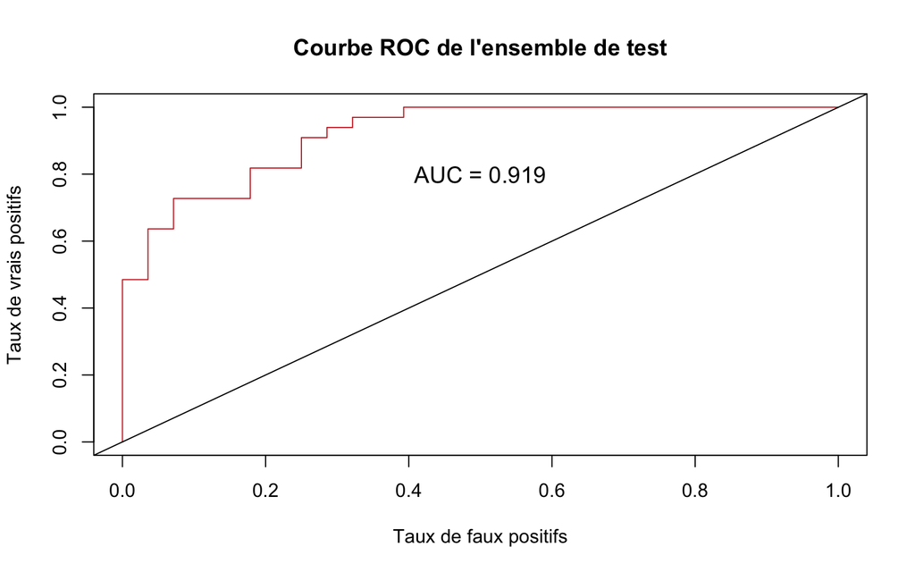

```r
# Courbe ROC
pred <- prediction(predicted_probs_test, test$target)
roc <- performance(pred, measure = "tpr", x.measure = "fpr")

# Calcul de l'AUC
auc <- performance(pred, measure = "auc")
auc_value <- round(unlist(slot(auc, "y.values")), 3)

# Plot de la courbe ROC
plot(roc, xlab = "Taux de faux positifs", ylab = "Taux de vrais positifs", col = "#CC3333", main = "Courbe ROC de l'ensemble de test")
abline(a = 0, b = 1)

# Ajout de l'AUC au graphique
text(0.5, 0.8, labels = paste("AUC =", auc_value), cex = 1.2, col = "black")
```

Dans notre cas, l’AUC est proche de 1 (environ 0.9) donc la prédiction semble être bonne.

# 7 Comparaison avec d’autres modèles

Pour terminer le projet, on compare le modèle de régression logistique à 2 autres modèles : un modèle de RadomForest et un modèle d’arbre de décision.

## 7.1 Déclaration des modèles

On construit d’abord un modèle de forêt aléatoire (*Random Forest*) qui est populaire en raison de sa capacité à produire des prédictions précises, à gérer des ensembles de données complexes et bruités, et à éviter le surajustement.

On construit ensuite un modèle d’arbre de décision, qui est plus approprié pour capturer des relations non linéaires entre les variables explicatives et la variable cible et des interactions complexes.

On peut afficher les matrices de confusions des modèles construits.

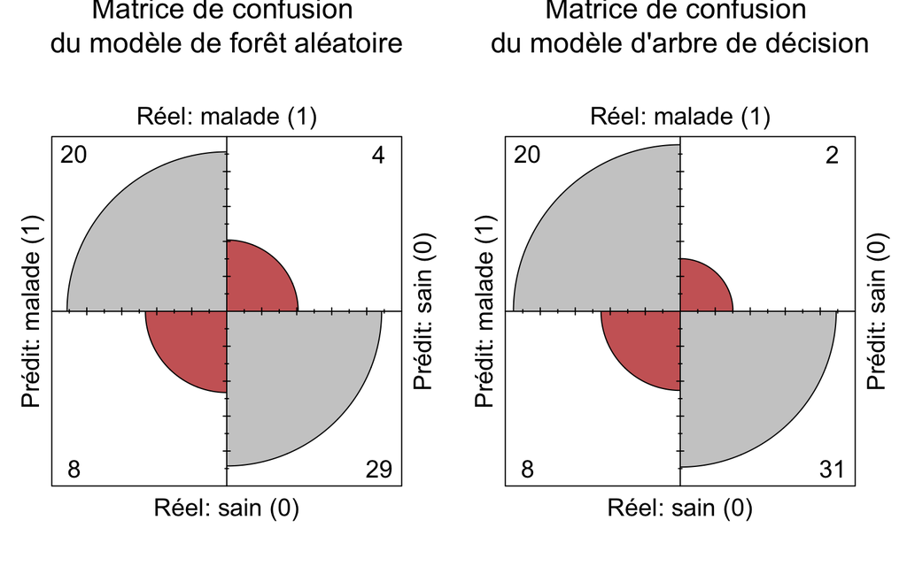

```r
par(mfrow=c(1, 2))
# Affichage de la matrice de confusion de la forêt aléatoire
ctable <- as.table(results_rf,
                   nrow = 2,
                   byrow = TRUE)
# Définir les étiquettes "malade" et "sain" pour les lignes et colonnes
rownames(ctable) <- colnames(ctable) <- c("malade (1)", "sain (0)")

# Définir les étiquettes "Réel" et "Prédit"
dimnames(ctable) <- list(Réel = rownames(ctable), Prédit = colnames(ctable))

fourfoldplot(ctable,
             color = c("#CC6666", "#CCCCCC"),
             conf.level = 0,
             margin = 1,
             main = "Matrice de confusion \ndu modèle de forêt aléatoire")

# Affichage de la matrice de confusion de l'arbre de décision
ctable <- as.table(results_tree,
                   nrow = 2,
                   byrow = TRUE)
# Définir les étiquettes "malade" et "sain" pour les lignes et colonnes
rownames(ctable) <- colnames(ctable) <- c("malade (1)", "sain (0)")

# Définir les étiquettes "Réel" et "Prédit"
dimnames(ctable) <- list(Réel = rownames(ctable), Prédit = colnames(ctable))

fourfoldplot(ctable,
             color = c("#CC6666", "#CCCCCC"),
             conf.level = 0,
             margin = 1,
             main = "Matrice de confusion \ndu modèle d'arbre de décision")
```

## 7.2 Comparaison des performances

```r
# Calcul de l'AUC RF
pred_rf <- prediction(predicted_probs_test_rf, test$target)
auc_rf <- performance(pred_rf, measure = "auc")
auc_value_rf <- round(unlist(slot(auc_rf, "y.values")), 3)

# Calcul de l'AUC Tree
pred_tree <- prediction(predicted_probs_test_tree, test$target)
# Calcul de l'AUC
auc_tree <- performance(pred_tree, measure = "auc")
auc_value_tree <- round(unlist(slot(auc_tree, "y.values")), 3)

# Extraction des valeurs spécifiques
specific_metrics <- c("Sensitivity", "Neg Pred Value", "Precision")

# Création d'un dataframe avec les valeurs spécifiques
metrics <- c("Sensibilité", "F1 Score", "Valeur prédictive négative", "Accuracy", "Nombre de faux négatifs", "AUC")
models <- c("Regression logistique", "Random Forest", "Arbre de décision")
data <- matrix(NA, nrow = length(models), ncol = length(metrics))
colnames(data) <- metrics
rownames(data) <- models

# Insertion des valeurs spécifiques dans le dataframe
data["Regression logistique", ] <- c(unlist(results$byClass[specific_metrics ]), results$overall['Accuracy'], results$table[1, 2], auc_value)
data["Random Forest",] <- c(unlist(results_rf$byClass[specific_metrics]), results_rf$overall['Accuracy'], results_rf$table[1, 2], auc_value_rf)
data["Arbre de décision",] <- c(unlist(results_tree$byClass[specific_metrics]), results_tree$overall['Accuracy'], results_tree$table[1, 2], auc_value_tree)

# Affichage du tableau
data %>%
  kbl(digits = c(3, 3, 3, 3, 1, 2), caption = "Comparaison des performances des différents modèles ") %>% # pour les arrondis et titres
  kable_styling()
```

Table 7.1: Comparaison des performances des différents modèles

[output not shown]

On obtient des modèles qui ont des performances assez similaires.

# 8 Conclusion

Dans le cadre de ce projet, axé sur l’explication et la prédiction des maladies cardiaques, nous avons développé et évalué un modèle de régression logistique, qui est un modèle facilement interprétable. Les performances de ce modèle se sont avérées prometteuses, démontrant une bonne capacité à expliquer et prédire la présence de maladies cardiaques. Ce modèle a été comparé à des approches alternatives telles que la forêt aléatoire et l’arbre de décision, qui ont montré des performances similaires.

D’autres modèles, comme le SVM, la classification naïve bayésienne, le KNN, ou le Gradient Boosting, pourraient être explorés pour améliorer la prédiction.

Des observations paradoxales ont été constatées dans l’application. Ces résultats inattendus pourraient s’expliquer par des interactions complexes entre les caractéristiques. Introduire des interactions entre les variables pourrait améliorer la capacité prédictive des modèles. De plus, des biais statistiques dus à la taille limitée de l’échantillon pourraient impacter certaines catégories sous-représentées. Enfin, certains facteurs externes importants, tels que les comportements, les facteurs environnementaux ou les conditions médicales spécifiques, n’ont pas été inclus dans l’étude. Prendre en compte ces éléments dans de futures recherches pourrait affiner les prédictions des maladies cardiaques.